# 2022-23 CTEC Data Exploratory Analysis

Final Project  
Data Science 1 with R (STAT 301-1)

Author

Sheena Tan

Published

December 7, 2023

**Github Repo Link**

https://github.com/stat301-1-2023-fall/final-project-1-sheena-tan.git

## Introduction

### Data Source

I am using data from Northwestern’s [Course and Teacher Evaluation Council (CTEC)](https://www.northwestern.edu/ctec) system, which is data available to students at Northwestern University. These evaluations provide ratings made by previous students regarding various Northwestern courses and their instructor(s), including information like how much time the student spent on the course, what degree requirements the course fulfilled for the student, what year and school the student is in, and ratings of the instruction and the course across several categories.

The data used in this project was scraped from [CTEC data](https://www.northwestern.edu/ctec) from the most recent academic year (2022-23) across six representative course departments, for each of the six Northwestern schools:

1. Psychology (PSYCH) for Weinberg,
2. Civil and Environmental Engineering (CIV_ENV) for McCormick,
3. Music (MUSIC) for Bienen,
4. Communication Studies (COMMS) for the School of Communications,
5. Journalism (JOUR) for Medill,
6. and School of Education & Social Policy Core (SESP) for SESP.

### Data Description

The data has a total of **5137 objects** across **12 variables**.

1. `school`: categorical variable; the school the department is from – denoted `mcmk` for McCormick, `jour` for Medill, `comm` for Comms, `bien` for Bienen, `sesp` for SESP, and `wnbg` for Weinberg
2. `dept`: categorical variable; the department the course is offered through – denoted `psych` for Psychology, `sesp` for SESP Core, `music` for Music, `comm_st` for Communication Studies , `jour` for Journalism, and `civ_env` for Civil and Environmental Engineering
3. `course_num`: the three digit course number
4. `course_term`: categorical variable; the quarter the course was offered – denoted `fall` for Fall 2022, `winter` for Winter 2023, and `spring` for Spring 2023
5. `instructor`: the name of the instructor
6. `inst_rating`: the mean of students’ responses to the prompt, *“Provide an overall rating of the instruction,”* rated out of 6
7. `course_rating`: the mean of students’ responses to the prompt, *“Provide an overall rating of the course,”* rated out of 6
8. `learn_rating`: the mean of students’ responses to the prompt, *“Estimate how much you learned in the course,”* rated out of 6
9. `challenge_rating`: the mean of students’ responses to the prompt, *“Rate the effectiveness of the course in challenging you intellectually,”* rated out of 6
10. `interest_rating`: the mean of students’ responses to the prompt, *“Rate the effectiveness of the instructor in stimulating your interest in the subject,”* rated out of 6
11. `hours_spent`: the mean of students’ responses to the prompt, *“Estimate the average number of hours per week you spent on this course outside of class and lab time.”*
12. `essay`: text responses to the prompt, *“Please summarize your reaction to this course focusing on the aspects that were most important to you.”*

### Data Preparation

Student essay responses for each class share all other variables. Therefore, the raw data only contains a complete entry for the first instance of each class, and following entries are empty except for differing student essay responses.

To address these missing values, cleaning occurred in three main steps: First, string values were changed to be missing values when empty. Second, missing values were filled from the nearest values above. Finally, the data was examined for missingness, and no remaining missingness (other than in the `essay` responses) was found.

## The Background

In the four years that I’ve been at Northwestern, I’ve heard my fair share of anecdotes, stereotypes, and stories about the students and classes in the different schools. *SESP classes are easy, but no one learns anything*; or *McCormick kids never leave their dorms because of how much they have to study*; or this or that class is really great, or this or that professor is really horrible.

However, CTECs do not provide a built-in mechanism to compare data across courses or across teachers, in a department or across departments. This project aimed to compare data across schools and classes to investigate any patterns that may be of interest, like:

- Which school learns the most from their classes?
- Does putting in more time make the class more rewarding?
- Which school has the best professors? Best classes?
- Does having a better professor influence how much students feel that they learn?
- Who is the most liked and most hated teacher in each department?
- What are the best classes overall and in each department?

## Here is what I found.

### Which school’s students spend the most time on their classes?

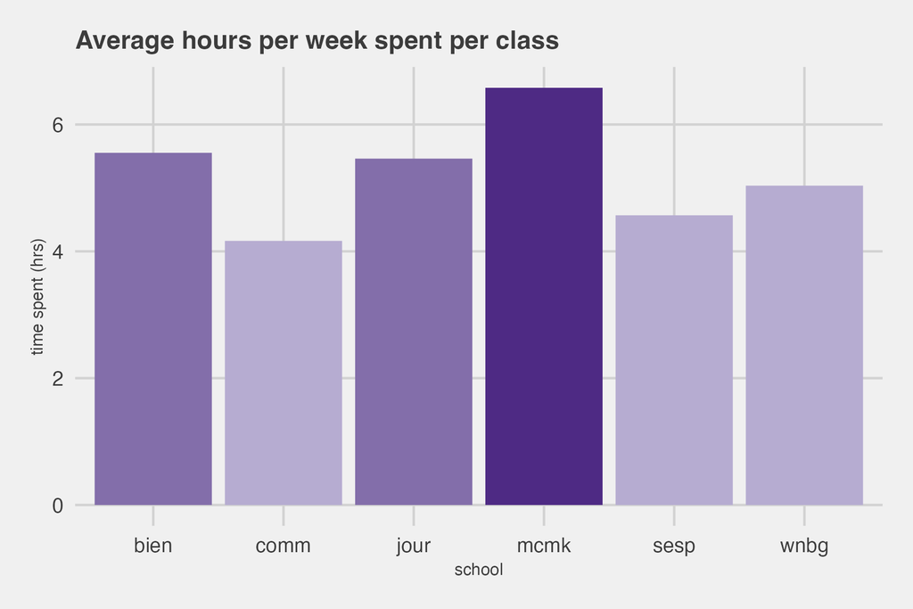

Hours Spent Studying By School

It seems some stereotypes have truth to them – McCormick students spend **significantly more** hours on average (6.58h) than students from other schools on their classes, as shown in the figure above.

### Which school’s students learn the most from their classes?

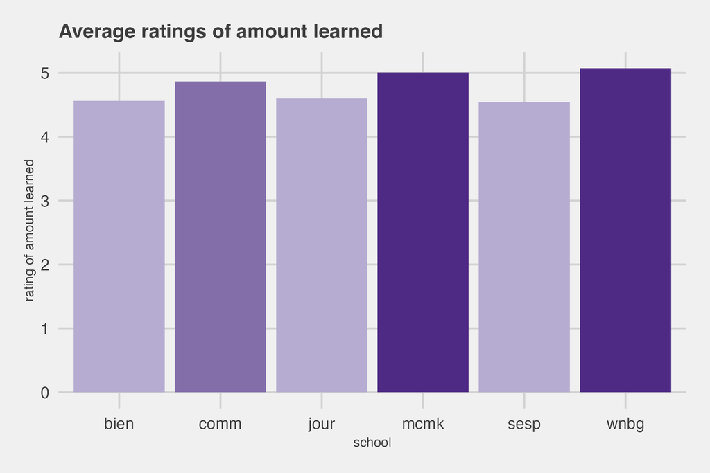

Amount Learned By School

The differences in ratings here are less dramatic, with students from all schools answering an average of >4 when asked to “Estimate how much [they] learned in the course,” on a 1 to 6 scale. However, McCormick and Weinberg students rate that they **learned the most** on average, being the only schools with an average learning rating greater than 5.

Once again, though, it seems stereotypes hold true – SESP students rated that they **learned the least** on average.

Putting together these results with the previous ones, it seems a trend is beginning to emerge. Could it be that the schools that spend the least time on their classes also tend to feel like they don’t learn as much? And could the opposite also be true? Let’s see.

### Does putting in more time make a class more rewarding?

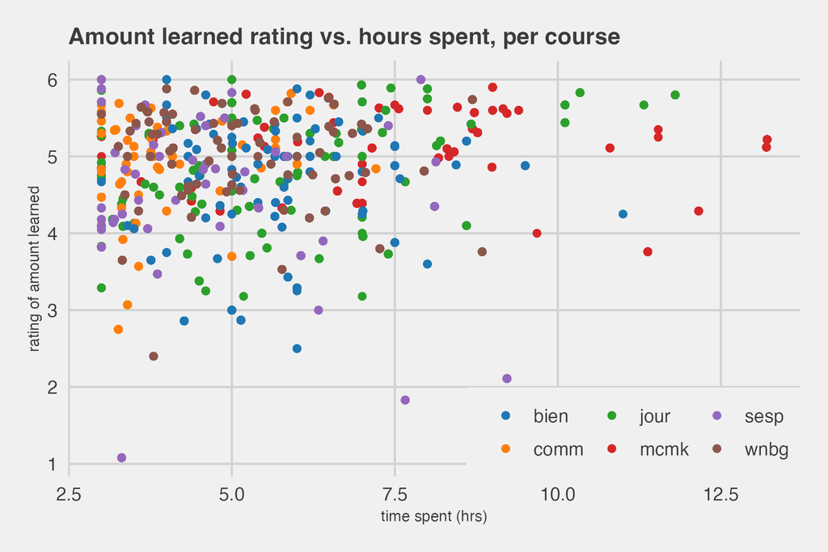

Time Spent Versus Amount Learned

In other words: **It doesn’t take a lot of time to feel like you learned a lot, but if it does take time, you’ll feel like you learned from it.**

Then what happens if we take a closer look at each school on their own?

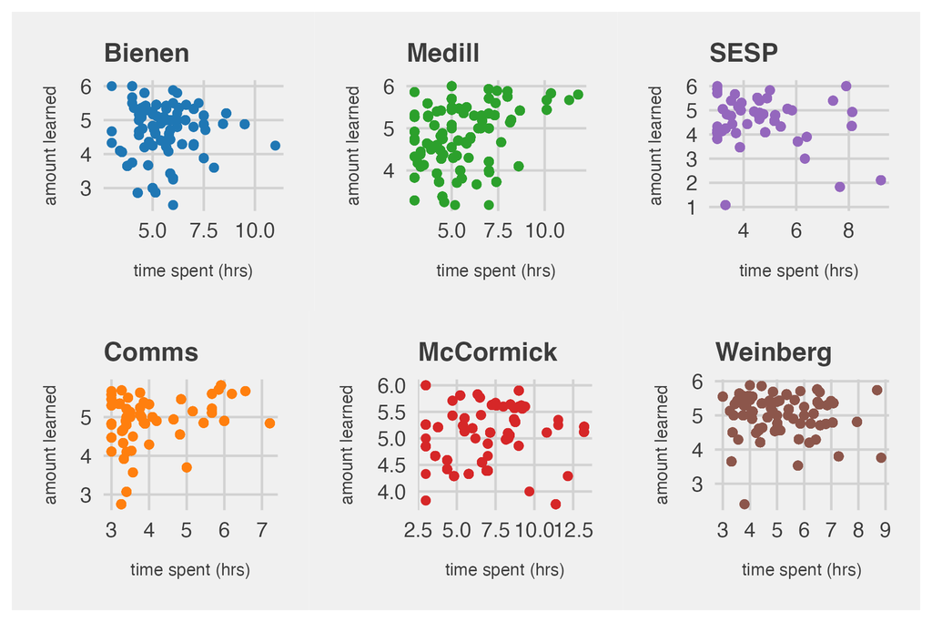

Time Spent Versus Amount Learned By School

Notably, *McCormick* classes were the only ones requiring **over 12.5 hours** of work per class. On the flip side, *SESP* classes were the only ones with a learning rating of **less than 2.**

Once again, the stereotypes do seem to be holding true. Naturally, this type of result makes us want to ask *why* such patterns exist. Could it be due to a difference in the type or amount of homework assigned? We could interview students to find out, but that’s beyond the scope of this project.

Alternatively, there might be a difference in the quality of professors between schools. So let’s look at professors next.

### Which school has the best professors?

Let’s define a new instructor measure rated out of 12, `inst_combined_rating`, by combining students’ responses to the prompt about overall rating of instruction, rated out of 6, and the prompt about how interesting the instructor is, also rated out of 6.

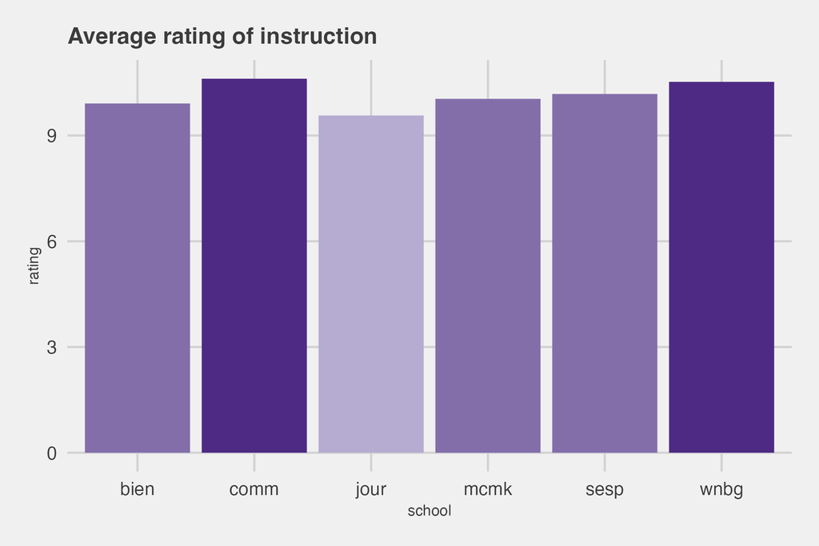

Instruction Rating By School

It looks like professors fall into three tiers: best, okay, and worst. The School of Comms and Weinberg have the **best professors**, with average instruction ratings of over 10.5. Medill has the **worst professors**, with a notably low average instruction rating of 9.57. In comparison, Bienen (9.91), McCormick (10.04), and SESP (10.17) all had **okay professors**, with average instruction ratings of around 10. My experience at Northwestern agrees with these ratings: **Medill has the absolute worst professors I’ve ever had. The professors in the School of Communications definitely practice what they preach. The other schools are a mixed bag.**

I was surprised by how high the Weinberg ratings were, however. It seems that *using a representative department does not model reality as well here, because of the drastic difference between departments* in Weinberg. The psychology department (which we look at in this project) is well-known for having spectacular professors, for example, whereas the chemistry department is notoriously hated. If I had the ability to look at data across all departments, I would expect to see results closer to 10.

Glancing at these instructor results in comparison to the results from our learning analysis, a relationship does not immediately appear. Let’s see what else the data has to say.

### Does having a better professor influence how much students learn?

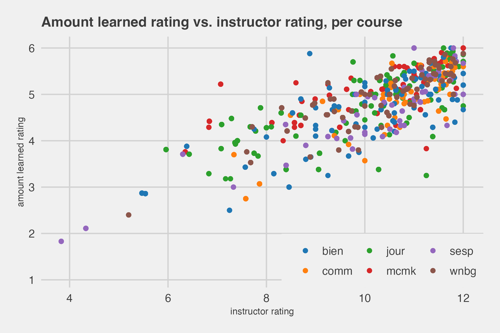

Amount Learned Versus Instructor Rating By School

There is a **strong linear correlation** between how good the professor is and how much students feel that they learn in a class. We can’t tell which causes what, but there certainly appears to be a relationship between these two variables. Maybe having a better professor helps students learn more, or maybe feeling like they learned a lot in a class is part of what makes students give their instructors high ratings, or both.

When I’m rating my instructors on CTECs, for example, I wouldn’t rank their instruction very highly if I didn’t feel like they taught me anything. At the same time, if a great professor taught me, I’d probably learn a lot from them.

We’ve looked at which schools have the best professors. How about classes?

### Which school has the best classes?

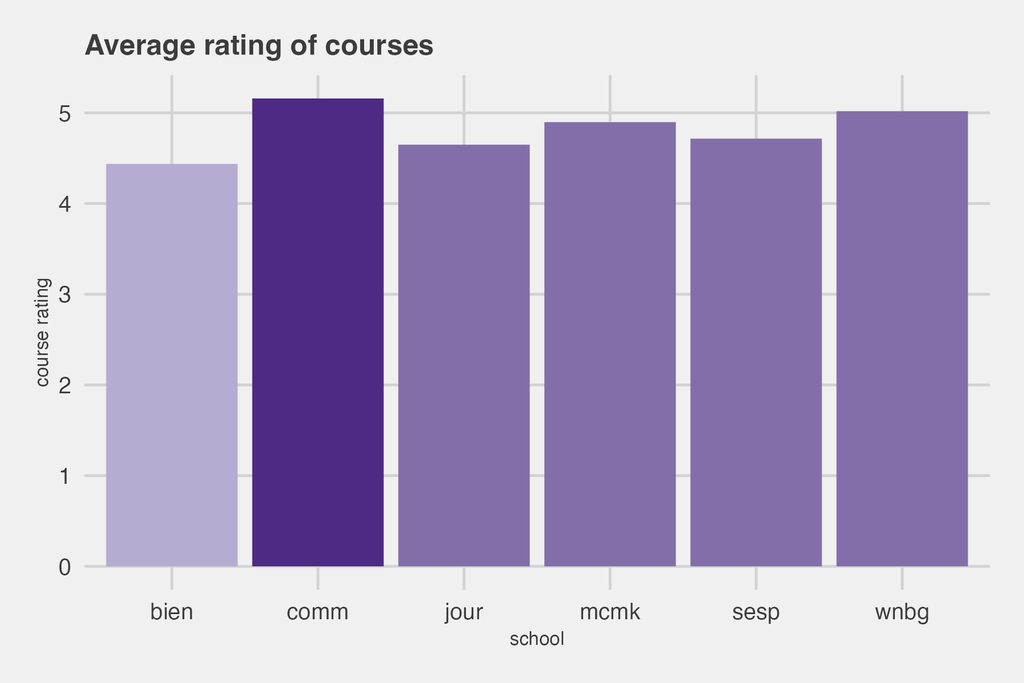

Course Rating By School

From a numerical rating alone, it’s difficult to rank which school’s classes are definitively best. Bienen classes are rated worse than all the other schools on average (4.44), but even the school with the highest average course ratings, Comms (5.16), was not that much higher in ratings than the other schools: Medill (4.65), McCormick (4.90), SESP (4.72), and Weinberg (5.02).

CTECs provide us with another powerful measure to analyze course information: open-ended responses. Reading through and analyzing all 5000+ short-response entries would take us forever, but not for our computers!

We perform a [sentiment analysis](https://www.tidytextmining.com/sentiment) on the open-ended essay responses and define a new measure `sentiment_rating` denoting how positive the student feedback is for each course. We will utilize the `afinn` sentiment lexicon in the `tidytext` package to determine what is considered positive or negative. The AFINN lexicon assigns a score between -5 and 5 to words of various sentiments, with negative scores indicating negative sentiment and positive scores indicating positive sentiment.

Let’s see what these short-response entries have to tell us.

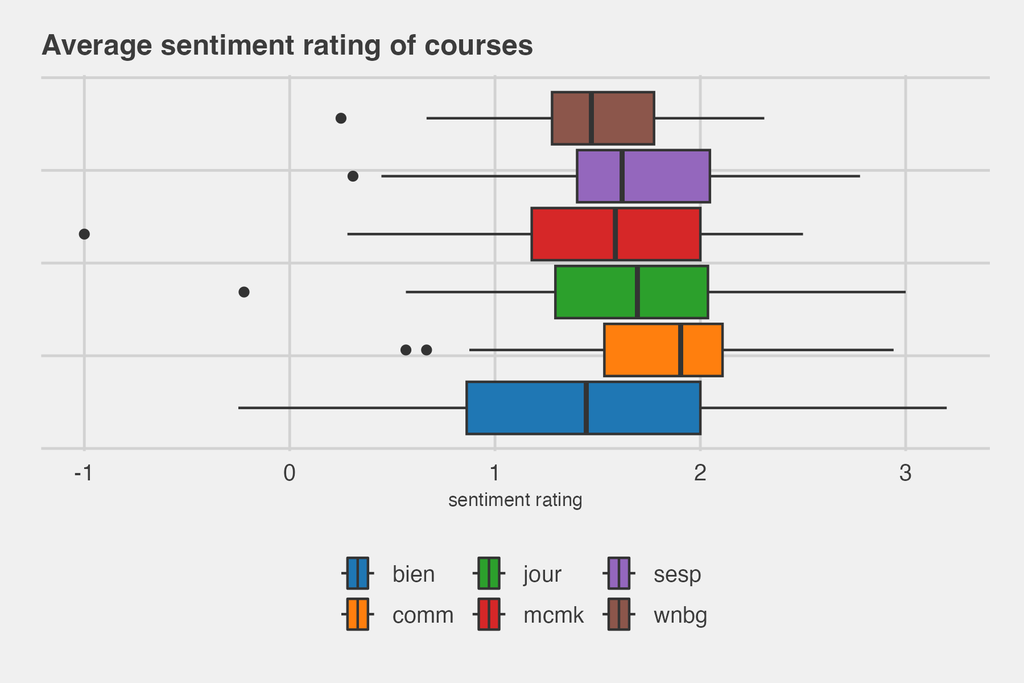

Sentiment Ratings by School

We define a new variable, `essay_sentiment`, which averages the sum of all of the sentiment scores for each essay response by course, section, and instructor by the number of responses there were for that course, section, and instructor. The higher the sentiment score, the more positive the responses were collectively, and the lower the sentiment score, the more negative the responses were collectively.

The results reinforce what we see from the original course rating measure. Bienen course sentiments average lower than the others (1.44), and Comms course sentiments slightly higher (1.81), but none of the schools are different enough from each other to definitively argue that certain schools’ courses are better than others: Medill (1.659030), McCormick (1.486994), SESP (1.674196), Weinberg (1.474052).

Course sentiment typically **averages to be positive overall**, which might show that Northwestern courses are generally pretty satisfactory, but could also be due to a general tendency for people to be polite when writing about their opinions publicly.

### So… which school is the best?

Let’s visualize the evaluations that we’ve been making.

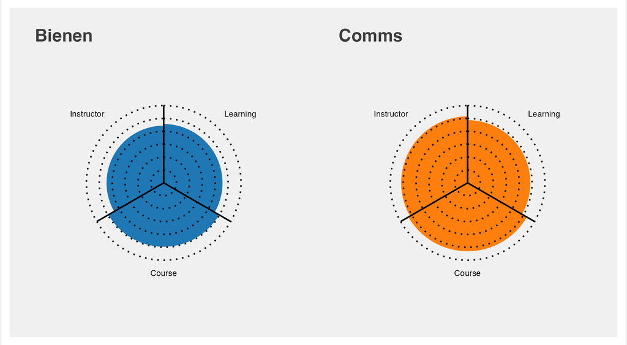

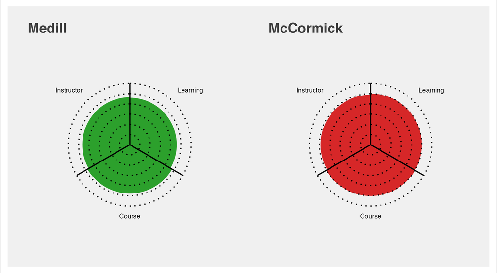

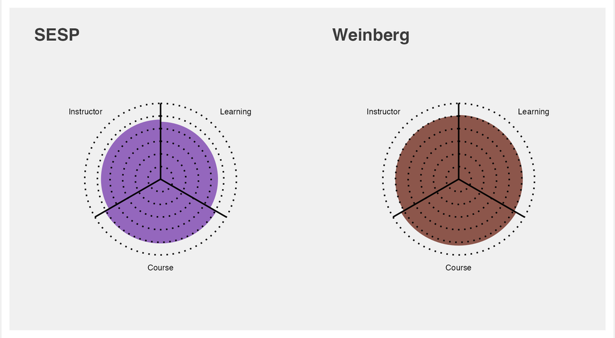

Radar chart by school

In summary:

## Conclusion

This project aimed to explore and compare student evaluations across course departments representing each of the six Northwestern schools using CTEC data from the academic year 2022-23, to better understand the similarities and differences between them.

Several key findings emerged from the investigation:

**Surprises and Future Work:**

- Surprisingly, certain stereotypes about schools and departments held true in the data, validating anecdotal perceptions.
- I was most surprised by the relationship between Time Spent and Learning, but the finding makes a lot of sense.
- As briefly mentioned in the report, potential avenues for future research could explore the reasons behind these findings, as there was only so much I could make claims about without experimental data. I would be interested in running an open-coding on the open-ended responses, or otherwise interviewing students, to better understand **what** is causing these differences in reported student learning beyond only teacher quality and time spent.
- Also, this investigation would have been much more robust with data across multiple departments within a school to account for nuances within departments with diverse reputations.

In summary, this project provides valuable insights into the dynamics of student experiences across Northwestern schools. The findings offer a foundation for future inquiries into the factors influencing these experiences and suggests areas for improvement within the academic landscape of each school.

## Appendix: Extra Explorations

### Who are the most and least liked teachers in each department?

**Most liked:**

| school | dept | course_num | course_term | instructor | inst_combined_rating | course_rating | learn_rating | interest_rating | hours_spent |
| --- | --- | --- | --- | --- | --- | --- | --- | --- | --- |
| mcmk | civ_env | 302 | spring | Patrick Croke | 12 | 6.00 | 6.00 | 6 | 3.00 |
| wnbg | psych | 343 | winter | Renee Engeln | 12 | 6.00 | 5.88 | 6 | 4.00 |
| sesp | sesp | 218 | fall | Josiah Rosario | 12 | 6.00 | 5.88 | 6 | 3.00 |
| jour | jour | 305 | winter | Bob Rowley | 12 | 5.71 | 5.86 | 6 | 3.00 |
| jour | jour | 352 | fall | Peter Slevin | 12 | 5.86 | 5.71 | 6 | 7.00 |
| jour | jour | 384 | winter | Matthew Orr | 12 | 5.70 | 5.70 | 6 | 5.00 |
| comm | comm_st | 159 | spring | Julia Barnett | 12 | 5.33 | 5.67 | 6 | 3.00 |
| sesp | sesp | 251 | winter | Alex Gonzalez | 12 | 5.83 | 5.67 | 6 | 3.67 |
| comm | comm_st | 394 | winter | Jack Bandy | 12 | 5.90 | 5.60 | 6 | 5.67 |
| bien | music | 126 | spring | Vincent Ip | 12 | 5.18 | 5.45 | 6 | 6.64 |
| bien | music | 211 | fall | Sara Bowden | 12 | 4.90 | 5.20 | 6 | 8.60 |
| bien | music | 128 | fall | Susan Osborn | 12 | 5.33 | 5.00 | 6 | 5.66 |
| sesp | sesp | 392 | fall | Briellen Griffin | 12 | 5.17 | 5.00 | 6 | 5.84 |
| jour | jour | 390 | spring | Arionne Nettles | 12 | 5.00 | 4.75 | 6 | 3.00 |
| bien | music | 127 | winter | Karen Kan-Walsh | 12 | 5.33 | 4.67 | 6 | 4.33 |

**Least liked:**

| school | dept | course_num | course_term | instructor | inst_combined_rating | course_rating | learn_rating | interest_rating | hours_spent |
| --- | --- | --- | --- | --- | --- | --- | --- | --- | --- |
| jour | jour | 201 | winter | Desiree Hanford | 5.96 | 3.68 | 3.81 | 2.79 | 5.54 |
| mcmk | civ_env | 327 | fall | Wing Liu | 6.35 | 3.33 | 3.76 | 3.15 | 11.38 |
| comm | comm_st | 102 | fall | Eva Rubens Celem | 7.34 | 3.70 | 3.70 | 3.67 | 5.00 |
| bien | music | 216 | spring | Inna Naroditskaya | 5.47 | 2.69 | 2.87 | 2.53 | 5.14 |
| wnbg | psych | 360 | fall | William Revelle | 5.20 | 2.80 | 2.40 | 2.40 | 3.80 |
| sesp | sesp | 195 | spring | Matthew Easterday | 3.83 | 2.17 | 1.83 | 2.00 | 7.66 |

### Which classes have the most opinionated CTECs, either good or bad?

The most positive CTECs were for **BIEN 128** with Susan Osborn in the fall, receiving a 3.20 sentiment score; **BIEN 126** with Vincent Ip in the spring, receiving a 3.14 sentiment score; and **BIEN 127** with Annie Hsiao in the winter, receiving a 3.00 sentiment score.

The least positive CTECs were for **CIV_ENV 320** with Sinan Keten in the fall, receiving a -1.00 sentiment score; **BIEN 211** with Tomas Saccone in the fall, receiving a -0.25 sentiment score; and **JOUR 302** with Bradley Hamm in the spring, receiving a -0.22 sentiment score.

For the full listings, see `figures/exploratory_positive_ctecs.html` and `figures/exploratory_negative_ctecs.html`.

### For classes with more than one teacher, who taught it best?

When trying to choose who to take a course from, this information could come in really handy. I wish CTECs had a built-in comparison capacity!

| school | dept | course_num | course_term | instructor | inst_combined_rating | course_rating | learn_rating | interest_rating | hours_spent |
| --- | --- | --- | --- | --- | --- | --- | --- | --- | --- |
| mcmk | civ_env | 101 | fall | Kimberly Gray | 11.25 | 5.51 | 5.26 | 5.66 | 3.00 |
| mcmk | civ_env | 205 | fall | Elizabeth Durango-Cohen | 8.67 | 4.15 | 4.55 | 4.32 | 6.62 |
| mcmk | civ_env | 216 | winter | Madura Pathirage | 10.35 | 5.04 | 5.11 | 5.00 | 7.15 |
| mcmk | civ_env | 385 | fall | Scott Cyphers | 9.25 | 4.70 | 5.22 | 4.75 | 13.21 |
| mcmk | civ_env | 395 | spring | Elie Rekhess | 10.86 | 5.14 | 5.57 | 5.43 | 8.72 |
| comm | comm_st | 102 | winter | Christopher Dobmeier | 11.83 | 6.00 | 5.58 | 5.83 | 3.00 |
| comm | comm_st | 295 | fall | Moya Bailey | 11.69 | 5.69 | 5.46 | 5.77 | 4.85 |
| comm | comm_st | 394 | winter | Jack Bandy | 12.00 | 5.90 | 5.60 | 6.00 | 5.67 |
| comm | comm_st | 395 | spring | Sarah Syversen | 10.80 | 5.50 | 4.80 | 4.90 | 3.40 |
| jour | jour | 201 | fall | Michael Deas | 11.00 | 5.33 | 5.67 | 5.67 | 10.11 |
| jour | jour | 301 | fall | Karen Springen | 11.91 | 5.82 | 5.60 | 6.00 | 7.36 |
| jour | jour | 302 | fall | Jonathan Marshall | 9.94 | 4.63 | 4.79 | 4.81 | 6.01 |
| jour | jour | 311 | fall | Patti Wolter | 11.72 | 5.83 | 5.75 | 5.82 | 8.00 |
| jour | jour | 342 | fall | Zach Wise | 11.34 | 5.25 | 4.88 | 5.67 | 4.50 |
| jour | jour | 367 | fall | Patricia Loew | 11.80 | 5.82 | 5.27 | 5.90 | 3.73 |
| jour | jour | 370 | fall | Benjamin Holden | 7.88 | 3.88 | 4.71 | 3.88 | 5.35 |
| jour | jour | 377 | fall | Fernando Diaz | 11.40 | 5.50 | 5.50 | 5.70 | 5.80 |
| jour | jour | 384 | winter | Matthew Orr | 12.00 | 5.70 | 5.70 | 6.00 | 5.00 |
| jour | jour | 390 | spring | Karin Lydersen | 11.60 | 5.80 | 5.80 | 6.00 | 11.80 |
| bien | music | 111 | fall | Susan Piagentini | 11.24 | 5.09 | 5.45 | 5.74 | 5.18 |
| bien | music | 126 | fall | Vincent Ip | 11.82 | 5.55 | 5.36 | 5.91 | 6.28 |
| bien | music | 127 | fall | Annie Hsiao | 11.34 | 5.67 | 5.00 | 5.67 | 4.33 |
| bien | music | 211 | fall | Sara Bowden | 12.00 | 4.90 | 5.20 | 6.00 | 8.60 |
| bien | music | 226 | fall | Raymond Massoud | 10.60 | 4.00 | 4.40 | 5.20 | 5.40 |
| wnbg | psych | 101 | fall | Harry David Smith | 11.80 | 5.70 | 5.00 | 6.00 | 3.40 |
| wnbg | psych | 101 | fall | Benjamin Gorvine | 11.80 | 5.80 | 5.40 | 5.90 | 5.00 |
| wnbg | psych | 110 | winter | Renee Engeln | 11.33 | 5.32 | 5.32 | 5.66 | 6.56 |
| wnbg | psych | 205 | spring | Almaz Mesghina | 11.75 | 5.70 | 5.45 | 5.75 | 5.65 |
| wnbg | psych | 213 | fall | Galen Bodenhausen | 10.10 | 5.13 | 5.00 | 4.96 | 3.75 |
| sesp | sesp | 201 | winter | Terri Sabol | 10.20 | 4.80 | 4.93 | 4.93 | 8.13 |
| sesp | sesp | 251 | fall | Alex Gonzalez | 11.86 | 5.67 | 5.71 | 6.00 | 3.00 |
| sesp | sesp | 272 | winter | Briellen Griffin | 11.43 | 5.47 | 5.40 | 5.64 | 3.53 |
| sesp | sesp | 392 | spring | Ritu Tripathi | 11.13 | 5.17 | 4.83 | 5.55 | 3.36 |

### Does class level (100-200-300) determine if students feel like they learn more?

It looks like on average, students feel like they learn *more* from 100-level courses than 200-level courses! Could it be because 200-level courses are the required courses, whereas 100-level courses are typically elective seminars? The highest learning rating values are almost all 300-level courses though.

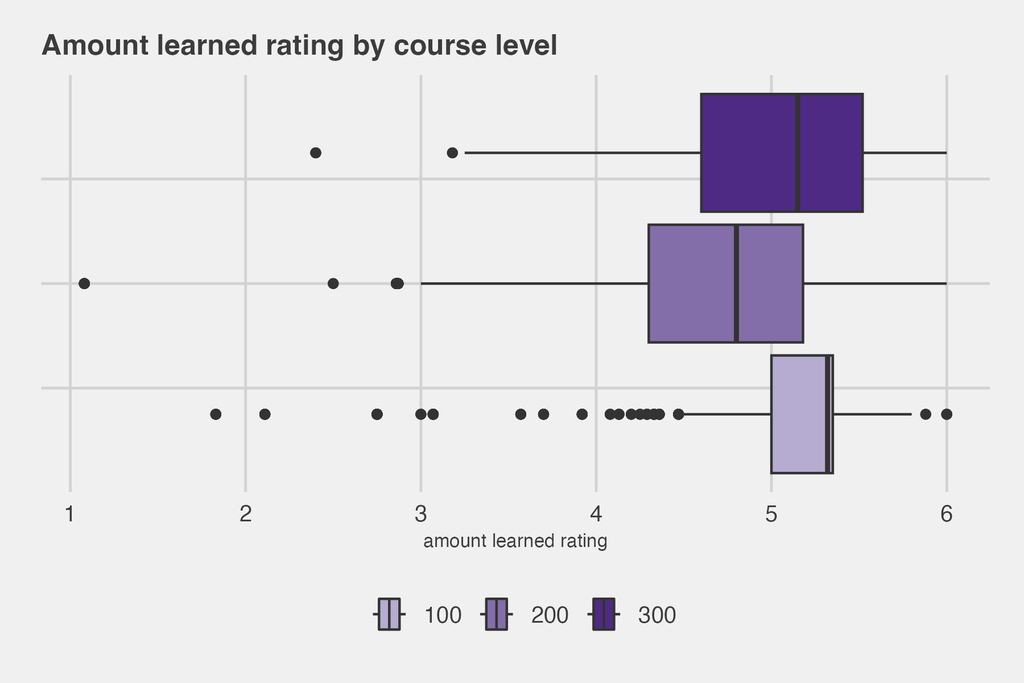

Learning rating by course level

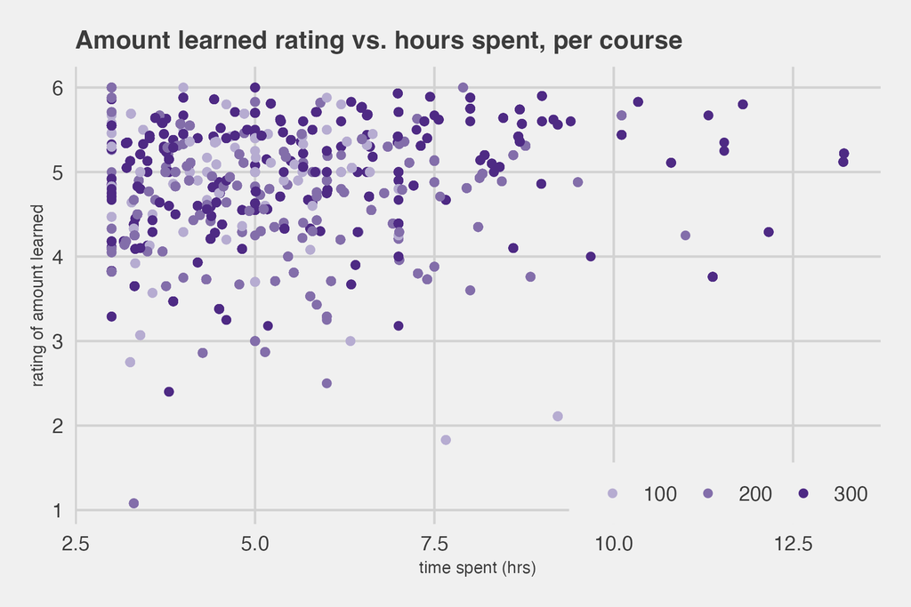

Learning vs hours spent by course level

### How valid are our measures?

I made the decision to use `course_rating` as a measure of course quality, because the phrasing of the question prompt addresses the course overall. However, the other measures of course quality that we developed, `challenge_rating` and `essay_sentiment`, are significantly correlated to `course_rating`.

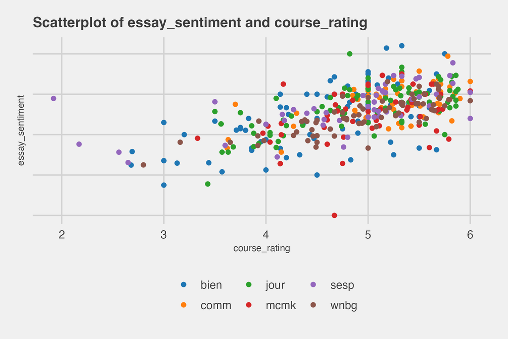

Scatterplot of essay_sentiment and course_rating

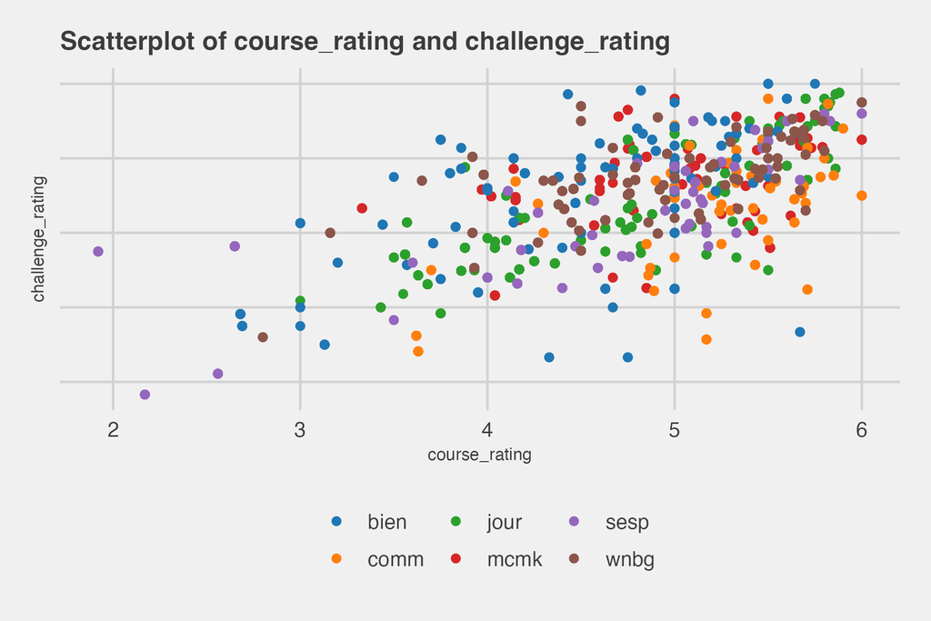

Scatterplot of course_rating and challenge_rating